# Replication of Rich & Gureckis (2018)

Josh de Leeuw, Rachel Ostrowski, Miles Bader

# Participants

Our target analytic sample size is 474 participants. A total of 474 completed the experiment. Of these, 0 reported using pen and paper or some other aid to help remember features of the bees, and were excluded from the analysis. This left a total of 474 participants in the analytic data set. There were 223 subjects in the full information condition and 251 subjects in the conditional information condition.

# Learning Phase Performance

Following Rich and Gureckis (2018), we classified learner performance as following a 2D rule if 15 of 16 trials in a block were correct. We classified participants as using a 1D rule if 15 of 16 trials in a block followed the correct decision criteria if the participant was only attending to one dimension. We treated the test phase as a single block of 32 trials, requiring 30 of 32 trials to follow a rule.

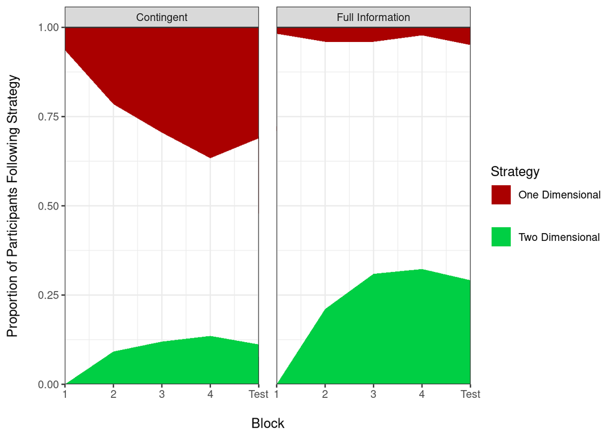

# Test Phase Accuracy

The critical hypothesis for the SCORE replication is

> H*: Participants in the contingent feedback condition will adopt an inferior one-dimension categorization strategy more often than participants in the full-information condition.

> Expected pattern of results: Participants in the contingent feedback condition will have a higher average 1D score compared to participants in the full-information condition.

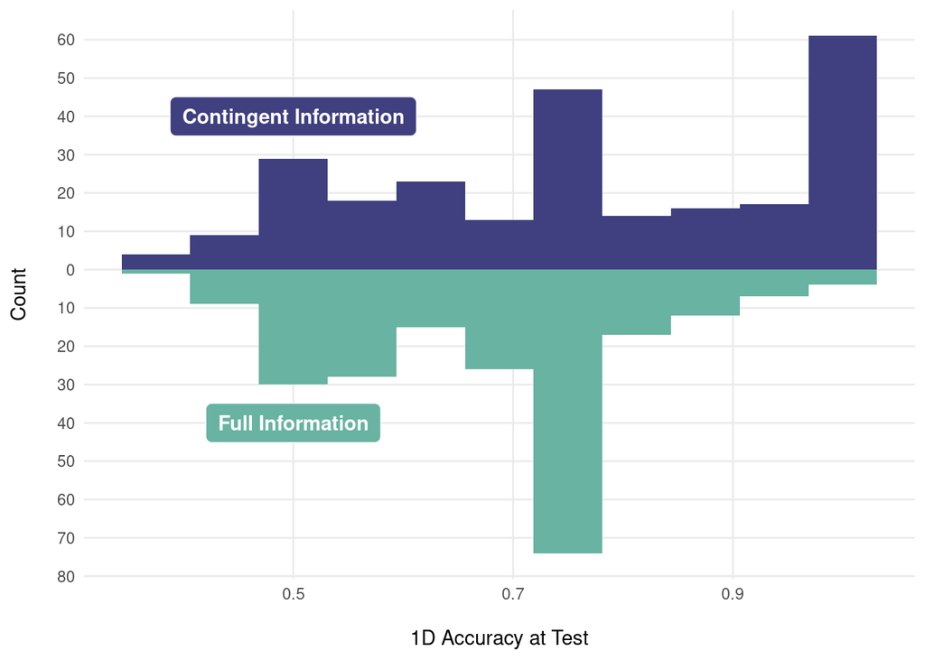

Histogram of 1D accuracy scores for each condition.